# Study 1 - Sokoban

Mike

2025-02-04

## Importing Data and Preprocessing

Our raw dataset consists of a file which includes data for each trial. Each participant also completed a survey, which we can match to the trial data with the prolific ID. We first preprocess the data by converting each column into their proper data types.

```r
raw_data <- fromJSON("fullstudy.combined.json")
raw_survey <- fromJSON("fullstudy.surveys.json")

numeric_cols_data <- c("aha1", "aha2", "aha3", "correctValue", "completedLevel", "completedEarly", "difficultyValue", "durationAfterBreak",
                  "durationBeforeBreak", "durationBreak", "durationToBeatGame", "idleTime",
                  "incorrectValue", "nm1", "nm2", "nm3", "r1b", "r2b", "r3b", "scrollCount",
                  "sessionID", "stuckValue", "e1", "e2", "e3", "f1", "f2", "f3", "mw1", "mw2",
                  "mw3", "pw", "r1", "r2", "r3", "ra")

factor_cols_data <- c("condition", "levelNumber","prolificPID")

numeric_cols_survey <- c("age")

factor_cols_survey <- c("sex", "handedness", "trialOrder", "conditionOrder")

raw_data <- raw_data %>%
  mutate(
    across(all_of(numeric_cols_data), ~ as.numeric(.)),
    across(all_of(factor_cols_data), ~ as.factor(.)),
    condition = recode(condition,
                       "1" = "No Break",
                       "2" = "Non-HIS",
                       "3" = "HIS"
                       )
  )

raw_survey <- raw_survey %>%
  mutate(
    across(all_of(numeric_cols_survey), ~ as.numeric(.)),
    across(all_of(factor_cols_survey), ~ as.factor(.)),
    across(c(videoGameHours, smartphoneHours, digitalDeviceHours, shortFormVideoHours),
           ~ as.numeric(recode(.,
                               "lessThan1" = 1,
                               "1to2" = 2,
                               "2to3" = 3,
                               "3to4" = 4,
                               "5plus" = 5))),
    sokobanFamiliarity = as.numeric(recode(sokobanFamiliarity,
                            "notFamiliar" = 1,
                            "somewhatFamiliar" = 2,
                            "veryFamiliar" = 3
                                           ))
  )
```

## Exclusions

Note that there is not the expected ratio of 3 trials to 1 participant. This is because some individuals either timed out by being idle or did not complete the three practice trials within 10 minutes. Some participants also completed trials multiple times, likely because they refreshed the page or restarted the study. Furthermore, form submissions were sometimes duplicated internally. Some participants’ data were also not recorded for some trials, so we decide to remove all of their trials.

```r
problematic_ids <- raw_data %>%
  group_by(prolificPID) %>%
  summarise(row_count = n()) %>%
  filter(row_count != 3) %>%
  pull(prolificPID)

data <- raw_data %>%
  filter(
    !prolificPID %in% problematic_ids,
    prolificPID %in% raw_survey$prolificPID
    )

survey <- raw_survey %>%
  filter(
    completedAllLevels != 0,
    prolificPID %in% data$prolificPID,
    ) %>%
  distinct(prolificPID, .keep_all = TRUE)
```

Aside from these technical exclusions, we decided to improve the quality of data by removing participants that showed very low engagement during one of their trials. We removed participants who had only one or no move sets before or after the break. We also removed them if they went idle during the break periods (which should only last around 180 seconds plus the time it takes to respond to questions).

```r
participants_excluded <- data %>%
  group_by(prolificPID) %>%
  filter(
    any(completedLevel == 0 & lengths(afterBreakMovesets) < 2) |
    any(completedLevel == 0 & lengths(beforeBreakMovesets) < 2) |
    any(completedLevel == 0 & durationBreak > 360)
  )

data <- data %>%
  filter(!prolificPID %in% participants_excluded$prolificPID)
```

## Validity and Reliability of Measures

For each construct, we use each participant’s first possible use of the scale during the first trial (since participants could possibly respond to each scale multiple times). This would exclude participants who completed the puzzle early on their first trial and those that are in the no break condition for the first puzzle.

```r
items <- data %>%
  filter(completedEarly == 0, condition != "No Break") %>%
  left_join(
    survey %>%
      mutate(first_trial = substr(trialOrder, 1, 1)) %>%
      select(prolificPID, first_trial),
    by = "prolificPID"
  ) %>%
  filter(levelNumber == first_trial) %>%
  select(starts_with("aha"), starts_with("nm"), starts_with("e"), starts_with("f"), starts_with("mw"), r1b, r2b, r3b, -first_trial) %>%
  drop_na()
```

We first use confirmatory factor analysis to check for convergent and divergent validity. Important variables include those used as a manipulation check (heightened enjoyment, focused immersion, and mind-wandering, insight experience) and supplemental variables (perceived use of new moves, resources).

```r
fa(items, nfactors = 6, rotate = "oblimin")
```

```
## Factor Analysis using method =  minres
## Call: fa(r = items, nfactors = 6, rotate = "oblimin")
## Standardized loadings (pattern matrix) based upon correlation matrix
##        MR5   MR1   MR2   MR4   MR3   MR6   h2    u2 com
## aha1  0.02 -0.07  0.92 -0.02  0.00 -0.10 0.82 0.178 1.0
## aha2 -0.06  0.02  0.95  0.05 -0.03  0.07 0.96 0.042 1.0
## aha3  0.04  0.06  0.85  0.02  0.07  0.05 0.79 0.215 1.0
## nm1   0.01 -0.11  0.04  0.82  0.06  0.01 0.78 0.223 1.1
## nm2  -0.03 -0.03 -0.02  0.93 -0.04  0.02 0.81 0.186 1.0
## nm3   0.11  0.11  0.08  0.84  0.04 -0.06 0.84 0.164 1.1
## e1    0.93  0.03  0.02  0.06 -0.09  0.07 0.93 0.069 1.0
## e2    0.92  0.02  0.02 -0.01  0.04  0.04 0.89 0.114 1.0
## e3    0.84 -0.12 -0.07  0.01  0.10 -0.05 0.77 0.229 1.1
## f1    0.06 -0.06 -0.06  0.08 -0.03  0.73 0.63 0.366 1.1
## f2    0.06 -0.18  0.11  0.00  0.14  0.60 0.71 0.295 1.4
## f3    0.17 -0.12  0.10 -0.15  0.06  0.67 0.78 0.223 1.4
## mw1   0.05  0.92 -0.01  0.01 -0.09  0.05 0.77 0.226 1.0
## mw2  -0.04  0.88 -0.02 -0.04  0.05 -0.09 0.92 0.079 1.0
## mw3  -0.08  0.81  0.02  0.00  0.06 -0.08 0.80 0.196 1.1
## r1b   0.09 -0.03  0.03  0.01  0.76 -0.04 0.60 0.399 1.0
## r2b   0.01 -0.01  0.04 -0.02  0.90 -0.02 0.81 0.186 1.0
## r3b  -0.15  0.07 -0.09  0.18  0.63  0.25 0.56 0.437 1.7
##
##                        MR5  MR1  MR2  MR4  MR3  MR6
## SS loadings           2.71 2.64 2.61 2.42 1.97 1.82
## Proportion Var        0.15 0.15 0.15 0.13 0.11 0.10
## Cumulative Var        0.15 0.30 0.44 0.58 0.69 0.79
## Proportion Explained  0.19 0.19 0.18 0.17 0.14 0.13
## Cumulative Proportion 0.19 0.38 0.56 0.73 0.87 1.00
##
##  With factor correlations of
##       MR5   MR1   MR2   MR4   MR3   MR6
## MR5  1.00 -0.48  0.14  0.26  0.11  0.54
## MR1 -0.48  1.00 -0.12 -0.06 -0.13 -0.63
## MR2  0.14 -0.12  1.00  0.49  0.24  0.19
## MR4  0.26 -0.06  0.49  1.00  0.34  0.11
## MR3  0.11 -0.13  0.24  0.34  1.00  0.29
## MR6  0.54 -0.63  0.19  0.11  0.29  1.00
##
## Mean item complexity =  1.1
## Test of the hypothesis that 6 factors are sufficient.
##
## df null model =  153  with the objective function =  16.63 with Chi Square =  1898.33
## df of  the model are 60  and the objective function was  0.94
##
## The root mean square of the residuals (RMSR) is  0.01
## The df corrected root mean square of the residuals is  0.02
##
## The harmonic n.obs is  122 with the empirical chi square  4.14  with prob <  1
## The total n.obs was  122  with Likelihood Chi Square =  103.97  with prob <  0.00037
##
## Tucker Lewis Index of factoring reliability =  0.933
## RMSEA index =  0.077  and the 90 % confidence intervals are  0.052 0.102
## BIC =  -184.27
## Fit based upon off diagonal values = 1
## Measures of factor score adequacy
##                                                    MR5  MR1  MR2  MR4  MR3  MR6
## Correlation of (regression) scores with factors   0.90 0.87 0.94 0.90 0.90 0.71
## Multiple R square of scores with factors          0.81 0.75 0.89 0.81 0.81 0.51
## Minimum correlation of possible factor scores     0.62 0.50 0.79 0.62 0.62 0.02
```

We assess internal consistency using Cronbach’s alpha.

```r
scales <- list(
  insight = items[,1:3],
  new_moves = items[,4:6],
  enjoyment = items[,7:9],
  immersion = items[,10:12],
  mind_wandering = items[,13:15],
  resources = items[,16:18]
)

sapply(scales, function(x) alpha(x)$total$raw_alpha)
```

```
##        insight      new_moves      enjoyment      immersion mind_wandering
##      0.9408975      0.9182255      0.9418180      0.8647786      0.9303154
##      resources
##      0.8357699
```

## General Performance

Completion data for each level

```r
completion <- data %>%
  group_by(levelNumber) %>%
  summarise(
    completed_count = sum(completedLevel),
    percent_completed = mean(completedLevel) * 100,
    sample_size = n()
  )

completion
```

```
## # A tibble: 3 × 4
##   levelNumber completed_count percent_completed sample_size
##   <fct>                 <dbl>             <dbl>       <int>
## 1 5                        85              31.2         272
## 2 7                       199              73.2         272
## 3 8                       157              57.7         272
```

Completion duration

```r
completion_duration <- data %>%
  filter(completedLevel == 1) %>%
  mutate(
    durationBreak = replace_na(durationBreak, 0),
    totalTime = durationToBeatGame - durationBreak
    ) %>%
  group_by(levelNumber) %>%
    summarize(duration_to_beat_puzzle = mean(totalTime, na.rm = TRUE))

completion_duration
```

```
## # A tibble: 3 × 2
##   levelNumber duration_to_beat_puzzle
##   <fct>                         <dbl>
## 1 5                              160.
## 2 7                              102.
## 3 8                              144.
```

For the ease of interpretation, rather than referring to the levels using the internal numbers, we can now classify based on their actual difficulties.

```r
data <- data %>%
  mutate(levelNumber = recode(levelNumber,
                              `5` = "hard",
                              `7` = "easy",
                              `8` = "medium")) %>%
  rename(level = levelNumber) %>%
  mutate(level = factor(level, levels = c("easy", "medium", "hard")))
```

For participants who did not complete puzzles early, we obtained brief 1-item measures for perceived difficulty and impasse.

```r
data %>%
  group_by(level) %>%
    summarize(
      average_difficulty = mean(difficultyValue, na.rm = TRUE)
    )
```

```
## # A tibble: 3 × 2
##   level  average_difficulty
##   <fct>               <dbl>
## 1 easy                 5.98
## 2 medium               6.08
## 3 hard                 5.92
```

```r
data %>%
  group_by(level) %>%
  summarize(
    average_impasse = mean(stuckValue, na.rm = TRUE)
  )
```

```
## # A tibble: 3 × 2
##   level  average_impasse
##   <fct>            <dbl>
## 1 easy              5.72
## 2 medium            5.88
## 3 hard              5.63
```

## Manipulation Checks

We first check whether the non-HIS and HIS condition were different from each other. Here, we average our items for each construct. For resources, we take the difference to get a measure of the changes in resources after taking a break.

```r
manipulation_data <- data %>%
  filter(condition != "No Break") %>%
  drop_na(f1, f2, f3, nm1, nm2, nm3, e1, e2, e3, mw1, mw2, mw3, r1b, r2b, r3b, r1, r2, r3, ra, pw) %>%
  mutate(
    focused_immersion = rowMeans(select(., f1, f2, f3)),
    heightened_enjoyment = rowMeans(select(., e1, e2, e3)),
    mind_wandering = rowMeans(select(., mw1, mw2, mw3)),
    perceived_use_of_new_strategies = rowMeans(select(., nm1, nm2, nm3)),
    resources_before = rowMeans(select(., r1b, r2b, r3b)),
    resources_after = rowMeans(select(., r1, r2, r3)),
    resources_difference = resources_after - resources_before
  )
```

Mixed effects models are used here to account for the repeated measures in our experiment (i.e., control for baseline differences among participants). Note that the intercept represents the value of the Non-HIS condition. For parsimony we do not include any control variables.

Focused immersion

```r
fi_lm <- lmer(focused_immersion ~ condition + (1|prolificPID), data = manipulation_data)
summary(fi_lm)
```

```
## Linear mixed model fit by REML. t-tests use Satterthwaite's method [
## lmerModLmerTest]
## Formula: focused_immersion ~ condition + (1 | prolificPID)
##    Data: manipulation_data
##
## REML criterion at convergence: 1213.5
##
## Scaled residuals:
##      Min       1Q   Median       3Q      Max
## -2.32671 -0.64176  0.04075  0.67388  1.83771
##
## Random effects:
##  Groups      Name        Variance Std.Dev.
##  prolificPID (Intercept) 0.5421   0.7363
##  Residual                1.5849   1.2589
## Number of obs: 339, groups:  prolificPID, 227
##
## Fixed effects:
##              Estimate Std. Error       df t value Pr(>|t|)
## (Intercept)    4.3341     0.1101 335.0397  39.359  < 2e-16 ***
## conditionHIS   0.5971     0.1431 191.0656   4.172 4.58e-05 ***
## ---
## Signif. codes:  0 '***' 0.001 '**' 0.01 '*' 0.05 '.' 0.1 ' ' 1
##
## Correlation of Fixed Effects:
##             (Intr)
## conditinHIS -0.634
```

```r
confint(fi_lm, method = "Wald")
```

```
##                  2.5 %    97.5 %
## .sig01              NA        NA
## .sigma              NA        NA
## (Intercept)  4.1182661 4.5499154
## conditionHIS 0.3165688 0.8775336
```

Heightened enjoyment

```r
he_lm <- lmer(heightened_enjoyment ~ condition + (1|prolificPID), data = manipulation_data)
summary(he_lm)
```

```
## Linear mixed model fit by REML. t-tests use Satterthwaite's method [
## lmerModLmerTest]
## Formula: heightened_enjoyment ~ condition + (1 | prolificPID)
##    Data: manipulation_data
##
## REML criterion at convergence: 1271.2
##
## Scaled residuals:
##     Min      1Q  Median      3Q     Max
## -2.6413 -0.7811  0.1560  0.7007  2.2502
##
## Random effects:
##  Groups      Name        Variance Std.Dev.
##  prolificPID (Intercept) 0.2229   0.4722
##  Residual                2.2528   1.5009
## Number of obs: 339, groups:  prolificPID, 227
##
## Fixed effects:
##              Estimate Std. Error       df t value Pr(>|t|)
## (Intercept)    3.2884     0.1195 336.7772   27.51   <2e-16 ***
## conditionHIS   1.9989     0.1656 202.8529   12.07   <2e-16 ***
## ---
## Signif. codes:  0 '***' 0.001 '**' 0.01 '*' 0.05 '.' 0.1 ' ' 1
##
## Correlation of Fixed Effects:
##             (Intr)
## conditinHIS -0.678
```

```r
confint(he_lm, method = "Wald")
```

```
##                 2.5 %   97.5 %
## .sig01             NA       NA
## .sigma             NA       NA
## (Intercept)  3.054174 3.522704
## conditionHIS 1.674256 2.323489
```

Mind-wandering

```r
mw_lm <- lmer(mind_wandering ~ condition + (1|prolificPID), data = manipulation_data)
summary(mw_lm)
```

```
## Linear mixed model fit by REML. t-tests use Satterthwaite's method [
## lmerModLmerTest]
## Formula: mind_wandering ~ condition + (1 | prolificPID)
##    Data: manipulation_data
##
## REML criterion at convergence: 1347.4
##
## Scaled residuals:
##     Min      1Q  Median      3Q     Max
## -2.0274 -0.8238  0.1344  0.7195  1.7392
##
## Random effects:
##  Groups      Name        Variance Std.Dev.
##  prolificPID (Intercept) 0.879    0.9376
##  Residual                2.299    1.5162
## Number of obs: 339, groups:  prolificPID, 227
##
## Fixed effects:
##              Estimate Std. Error       df t value Pr(>|t|)
## (Intercept)    4.3889     0.1344 334.4833  32.649  < 2e-16 ***
## conditionHIS  -0.6579     0.1731 183.6581  -3.801 0.000196 ***
## ---
## Signif. codes:  0 '***' 0.001 '**' 0.01 '*' 0.05 '.' 0.1 ' ' 1
##
## Correlation of Fixed Effects:
##             (Intr)
## conditinHIS -0.628
```

```r
confint(mw_lm, method = "Wald")
```

```
##                   2.5 %     97.5 %
## .sig01               NA         NA
## .sigma               NA         NA
## (Intercept)   4.1254595  4.6524148
## conditionHIS -0.9970325 -0.3186774
```

Active work on the puzzle during the break

```r
pw_lm <- lmer(pw ~ condition + (1|prolificPID), data = manipulation_data)
summary(pw_lm)
```

```
## Linear mixed model fit by REML. t-tests use Satterthwaite's method [
## lmerModLmerTest]
## Formula: pw ~ condition + (1 | prolificPID)
##    Data: manipulation_data
##
## REML criterion at convergence: 1239.8
##
## Scaled residuals:
##      Min       1Q   Median       3Q      Max
## -2.00447 -0.44442 -0.07953  0.20347  2.63989
##
## Random effects:
##  Groups      Name        Variance Std.Dev.
##  prolificPID (Intercept) 1.418    1.191
##  Residual                1.125    1.061
## Number of obs: 339, groups:  prolificPID, 227
##
## Fixed effects:
##              Estimate Std. Error       df t value Pr(>|t|)
## (Intercept)    2.6752     0.1171 323.0635  22.855  < 2e-16 ***
## conditionHIS  -0.6097     0.1280 162.5902  -4.765 4.17e-06 ***
## ---
## Signif. codes:  0 '***' 0.001 '**' 0.01 '*' 0.05 '.' 0.1 ' ' 1
##
## Correlation of Fixed Effects:
##             (Intr)
## conditinHIS -0.532
```

```r
confint(pw_lm, method = "Wald")
```

```
##                   2.5 %     97.5 %
## .sig01               NA         NA
## .sigma               NA         NA
## (Intercept)   2.4458157  2.9046495
## conditionHIS -0.8605267 -0.3589025
```

Changes in resources

```r
rd_lm <- lmer(resources_difference ~ condition + (1|prolificPID), data = manipulation_data)
summary(rd_lm)
```

```
## Linear mixed model fit by REML. t-tests use Satterthwaite's method [
## lmerModLmerTest]
## Formula: resources_difference ~ condition + (1 | prolificPID)
##    Data: manipulation_data
##
## REML criterion at convergence: 595.5
##
## Scaled residuals:
##     Min      1Q  Median      3Q     Max
## -2.8560 -0.5021  0.0271  0.4471  3.3140
##
## Random effects:
##  Groups      Name        Variance Std.Dev.
##  prolificPID (Intercept) 0.05208  0.2282
##  Residual                0.28306  0.5320
## Number of obs: 339, groups:  prolificPID, 227
##
## Fixed effects:
##               Estimate Std. Error        df t value Pr(>|t|)
## (Intercept)   -0.24704    0.04390 336.29360  -5.627 3.87e-08 ***
## conditionHIS   0.22997    0.05939 195.55922   3.872 0.000147 ***
## ---
## Signif. codes:  0 '***' 0.001 '**' 0.01 '*' 0.05 '.' 0.1 ' ' 1
##
## Correlation of Fixed Effects:
##             (Intr)
## conditinHIS -0.661
```

```r
confint(rd_lm, method = "Wald")
```

```
##                   2.5 %     97.5 %
## .sig01               NA         NA
## .sigma               NA         NA
## (Intercept)  -0.3330828 -0.1609907
## conditionHIS  0.1135609  0.3463700
```

Perceived recovery after break

```r
r_lm <- lmer(ra ~ condition + (1|prolificPID), data = manipulation_data)
summary(r_lm)
```

```
## Linear mixed model fit by REML. t-tests use Satterthwaite's method [
## lmerModLmerTest]
## Formula: ra ~ condition + (1 | prolificPID)
##    Data: manipulation_data
##
## REML criterion at convergence: 1280.8
##
## Scaled residuals:
##     Min      1Q  Median      3Q     Max
## -2.4403 -0.4551  0.1229  0.6640  1.8205
##
## Random effects:
##  Groups      Name        Variance Std.Dev.
##  prolificPID (Intercept) 0.561    0.749
##  Residual                2.020    1.421
## Number of obs: 339, groups:  prolificPID, 227
##
## Fixed effects:
##              Estimate Std. Error       df t value Pr(>|t|)
## (Intercept)    3.7943     0.1215 335.4786  31.221  < 2e-16 ***
## conditionHIS   0.9484     0.1604 186.1565   5.911 1.59e-08 ***
## ---
## Signif. codes:  0 '***' 0.001 '**' 0.01 '*' 0.05 '.' 0.1 ' ' 1
##
## Correlation of Fixed Effects:
##             (Intr)
## conditinHIS -0.645
```

```r
confint(r_lm, method = "Wald")
```

```
##                  2.5 %   97.5 %
## .sig01              NA       NA
## .sigma              NA       NA
## (Intercept)  3.5560933 4.032478
## conditionHIS 0.6339818 1.262903
```

Perceived use of new strategies/moves after a break

```r
nm_lm <- lmer(perceived_use_of_new_strategies ~ condition + (1|prolificPID), data = manipulation_data)
summary(nm_lm)
```

```
## Linear mixed model fit by REML. t-tests use Satterthwaite's method [
## lmerModLmerTest]
## Formula: perceived_use_of_new_strategies ~ condition + (1 | prolificPID)
##    Data: manipulation_data
##
## REML criterion at convergence: 1183.7
##
## Scaled residuals:
##     Min      1Q  Median      3Q     Max
## -2.9913 -0.3855  0.2648  0.4875  1.7853
##
## Random effects:
##  Groups      Name        Variance Std.Dev.
##  prolificPID (Intercept) 0.4612   0.6791
##  Residual                1.4800   1.2166
## Number of obs: 339, groups:  prolificPID, 227
##
## Fixed effects:
##                Estimate Std. Error         df t value Pr(>|t|)
## (Intercept)    5.244190   0.105293 335.603891  49.806   <2e-16 ***
## conditionHIS  -0.003022   0.137848 207.508313  -0.022    0.983
## ---
## Signif. codes:  0 '***' 0.001 '**' 0.01 '*' 0.05 '.' 0.1 ' ' 1
##
## Correlation of Fixed Effects:
##             (Intr)
## conditinHIS -0.639
```

```r
confint(nm_lm, method = "Wald")
```

```
##                  2.5 %    97.5 %
## .sig01              NA        NA
## .sigma              NA        NA
## (Intercept)   5.037820 5.4505605
## conditionHIS -0.273199 0.2671549
```

If Sokoban is a suitable non-routine problem, participants may have insight experiences if they are able to solve the puzzles. They should be more likely to have insight experiences after returning from a break, compared to those that completed the puzzle early.

```r
insight_data  <- data %>%
  drop_na(aha1, aha2, aha3) %>%
  mutate(
    aha = rowMeans(select(., aha1, aha2, aha3))
  )

i_lm <- lmer(aha ~ completedLevel + completedEarly + (1|prolificPID), data = insight_data)
summary(i_lm)
```

```
## Linear mixed model fit by REML. t-tests use Satterthwaite's method [
## lmerModLmerTest]
## Formula: aha ~ completedLevel + completedEarly + (1 | prolificPID)
##    Data: insight_data
##
## REML criterion at convergence: 2771.1
##
## Scaled residuals:
##     Min      1Q  Median      3Q     Max
## -3.5774 -0.5689  0.0595  0.5273  2.4892
##
## Random effects:
##  Groups      Name        Variance Std.Dev.
##  prolificPID (Intercept) 0.8219   0.9066
##  Residual                1.1943   1.0928
## Number of obs: 816, groups:  prolificPID, 272
##
## Fixed effects:
##                 Estimate Std. Error        df t value Pr(>|t|)
## (Intercept)      3.06493    0.08248 487.62581   37.16  < 2e-16 ***
## completedLevel   3.02033    0.11740 709.52766   25.73  < 2e-16 ***
## completedEarly  -0.49198    0.12330 706.77200   -3.99  7.3e-05 ***
## ---
## Signif. codes:  0 '***' 0.001 '**' 0.01 '*' 0.05 '.' 0.1 ' ' 1
##
## Correlation of Fixed Effects:
##             (Intr) cmpltL
## completdLvl -0.439
## compltdErly -0.006 -0.652
```

```r
confint(i_lm, method = "Wald")
```

```
##                     2.5 %     97.5 %
## .sig01                 NA         NA
## .sigma                 NA         NA
## (Intercept)     2.9032779  3.2265772
## completedLevel  2.7902191  3.2504381
## completedEarly -0.7336538 -0.2503109
```

Here, we can see participants rated higher insight (3 + 3) if they completed a level. However, if they completed a level early, their rating of perceived insight decreases (3 + 3 - .5).

## Main Analyses

First, we check if any of the control variables are relevant.

```r
main_data <- data %>%
  left_join(
    survey %>%
      select(prolificPID, age, handedness, sex, videoGameHours, smartphoneHours, sokobanFamiliarity, digitalDeviceHours, shortFormVideoHours, trialOrder, conditionOrder),
    by = "prolificPID"
  ) %>%
  filter(
    handedness %in% c("left","right"), # 5 participants put ambidextrous
    completedEarly != 1 # include only those who encountered manipulations
    ) %>%
  mutate(sex = factor(sex, levels = c(0, 1), labels = c("Female", "Male")),)
```

We compare a null model (with random intercepts) to other models.

```r
model1_null <- glmer(completedLevel ~ (1|prolificPID), family="binomial", control = glmerControl(optimizer = "bobyqa"), data = main_data)

model1_level <- glmer(completedLevel ~ level + (1|prolificPID), family="binomial", control = glmerControl(optimizer = "bobyqa"), data = main_data)

model1_condition<- glmer(completedLevel ~  condition + (1|prolificPID), family="binomial", control = glmerControl(optimizer = "bobyqa"), data = main_data)

model1_base <- glmer(completedLevel ~  level * condition + (1|prolificPID), family="binomial", control = glmerControl(optimizer = "bobyqa"), data = main_data)

model1_noint <- glmer(completedLevel ~ level + condition + (1|prolificPID), family="binomial", control = glmerControl(optimizer = "bobyqa"), data = main_data)

model1_age <- glmer(completedLevel ~  age + (1|prolificPID), family="binomial", control = glmerControl(optimizer = "bobyqa"), data = main_data)

model1_sex <- glmer(completedLevel ~   sex + (1|prolificPID), family="binomial", control = glmerControl(optimizer = "bobyqa"), data = main_data)

model1_handedness <- glmer(completedLevel ~   handedness + (1|prolificPID), family="binomial", control = glmerControl(optimizer = "bobyqa"), data = main_data)

model1_videoGames <- glmer(completedLevel ~   videoGameHours + (1|prolificPID), family="binomial", control = glmerControl(optimizer = "bobyqa"), data = main_data)

model1_smartphones <- glmer(completedLevel ~   smartphoneHours + (1|prolificPID), family="binomial", control = glmerControl(optimizer = "bobyqa"), data = main_data)

model1_sokoban <- glmer(completedLevel ~   sokobanFamiliarity + (1|prolificPID), family="binomial", control = glmerControl(optimizer = "bobyqa"), data = main_data)

model1_digitalDevice <- glmer(completedLevel ~   digitalDeviceHours + (1|prolificPID), family="binomial", control = glmerControl(optimizer = "bobyqa"), data = main_data)

model1_shortFormVideos <- glmer(completedLevel ~   shortFormVideoHours + (1|prolificPID), family="binomial", control = glmerControl(optimizer = "bobyqa"), data = main_data)

model1_trialOrder <- glmer(completedLevel ~   trialOrder + (1|prolificPID), family="binomial", control = glmerControl(optimizer = "bobyqa"), data = main_data)

model1_conditionOrder <- glmer(completedLevel ~  conditionOrder + (1|prolificPID), family="binomial", control = glmerControl(optimizer = "bobyqa"), data = main_data)

models1 <- list(
  null = model1_null,
  level = model1_level,
  condition = model1_condition,
  noint = model1_noint,
  base = model1_base,
  age = model1_age,
  sex = model1_sex,
  handedness = model1_handedness,
  videoGames = model1_videoGames,
  smartphones = model1_smartphones,
  sokoban = model1_sokoban,
  digitalDevice = model1_digitalDevice,
  shortFormVideos = model1_shortFormVideos,
  trialOrder = model1_trialOrder,
  conditionOrder = model1_conditionOrder
)

aic_results1 <- sapply(models1, AIC)
aic_results1 <- sort(aic_results1)
aic_results1
```

```
##           level           noint            base             sex      trialOrder
##        629.7355        631.7117        638.3125        657.1704        659.3084
##     smartphones             age            null      videoGames      handedness
##        662.2627        663.1969        663.5225        663.8692        663.9336
## shortFormVideos         sokoban   digitalDevice       condition  conditionOrder
##        664.9993        665.2521        665.4753        666.1675        671.4257
```

```r
bic_results1 <- sapply(models1, BIC)
bic_results1 <- sort(bic_results1)
bic_results1
```

```
##           level           noint             sex            null     smartphones
##        646.8720        657.4165        670.0228        672.0908        675.1151
##             age      videoGames      handedness shortFormVideos         sokoban
##        676.0493        676.7216        676.7860        677.8517        678.1045
##   digitalDevice            base       condition      trialOrder  conditionOrder
##        678.3277        681.1538        683.3040        689.2974        701.4146
```

The model with level as a predictor performs the best. Sex is a relevant covariate that improves the model fit. Most models agree in terms of what variable or interaction is significant. Males seem to perform considerably better than females on solving Sokoban puzzles.

```r
model1_level_sex <- glmer(completedLevel ~  level + sex + (1|prolificPID), family="binomial", control = glmerControl(optimizer = "bobyqa"), data = main_data)

anova(model1_level_sex, model1_level)
```

```
## Data: main_data
## Models:
## model1_level: completedLevel ~ level + (1 | prolificPID)
## model1_level_sex: completedLevel ~ level + sex + (1 | prolificPID)
##                  npar    AIC    BIC  logLik -2*log(L)  Chisq Df Pr(>Chisq)
## model1_level        4 629.74 646.87 -310.87    621.74
## model1_level_sex    5 622.44 643.86 -306.22    612.44 9.2947  1   0.002298 **
## ---
## Signif. codes:  0 '***' 0.001 '**' 0.01 '*' 0.05 '.' 0.1 ' ' 1
```

Our primary model will include only level and sex.

```r
model1_data <- data %>%
  left_join(
    survey %>%
      select(sex, prolificPID),
    by = "prolificPID"
  ) %>%
  filter(
    completedEarly != 1
    ) %>%
  mutate(sex = factor(sex, levels = c(0, 1), labels = c("Female", "Male")),)

model1_final <- glmer(completedLevel ~  level + sex + (1|prolificPID), family="binomial", control = glmerControl(optimizer = "bobyqa"), data = model1_data)

summary(model1_final)
```

```
## Generalized linear mixed model fit by maximum likelihood (Laplace
##   Approximation) [glmerMod]
##  Family: binomial  ( logit )
## Formula: completedLevel ~ level + sex + (1 | prolificPID)
##    Data: model1_data
## Control: glmerControl(optimizer = "bobyqa")
##
##       AIC       BIC    logLik -2*log(L)  df.resid
##     623.9     645.3    -306.9     613.9       534
##
## Scaled residuals:
##     Min      1Q  Median      3Q     Max
## -1.1056 -0.6053 -0.4133  0.9643  2.7045
##
## Random effects:
##  Groups      Name        Variance Std.Dev.
##  prolificPID (Intercept) 0.4151   0.6442
## Number of obs: 539, groups:  prolificPID, 254
##
## Fixed effects:
##             Estimate Std. Error z value Pr(>|z|)
## (Intercept)  -0.5868     0.2258  -2.599  0.00936 **
## levelmedium  -0.2652     0.2530  -1.048  0.29453
## levelhard    -1.4813     0.2821  -5.251 1.51e-07 ***
## sexMale       0.6910     0.2299   3.006  0.00265 **
## ---
## Signif. codes:  0 '***' 0.001 '**' 0.01 '*' 0.05 '.' 0.1 ' ' 1
##
## Correlation of Fixed Effects:
##             (Intr) lvlmdm lvlhrd
## levelmedium -0.642
## levelhard   -0.500  0.544
## sexMale     -0.499  0.010 -0.127
```

```r
r.squaredGLMM(model1_final, null = model1_null)
```

```
##                    R2m       R2c
## theoretical 0.12972424 0.2272186
## delta       0.09732719 0.1704735
```

```r
confint(model1_final, method = "Wald")
```

```
##                  2.5 %     97.5 %
## .sig01              NA         NA
## (Intercept) -1.0293674 -0.1442088
## levelmedium -0.7611471  0.2306906
## levelhard   -2.0342063 -0.9283823
## sexMale      0.2404481  1.1414866
```

```r
exp(fixef(model1_final))
```

```
## (Intercept) levelmedium   levelhard     sexMale
##   0.5561106   0.7670309   0.2273433   1.9956451
```

```r
exp(confint(model1_final, parm = "beta_", method="Wald"))
```

```
##                 2.5 %    97.5 %
## (Intercept) 0.3572329 0.8657069
## levelmedium 0.4671303 1.2594695
## levelhard   0.1307842 0.3951925
## sexMale     1.2718189 3.1314201
```

We run a similar set of comparisons for the dependent variable: duration after break (to complete level).

```r
completed_data <- main_data %>%
  filter(completedLevel == 1)

model2_null <- lmer(durationAfterBreak ~ (1|prolificPID), data = completed_data)

model2_condition <- lmer(durationAfterBreak ~   condition + (1|prolificPID), data = completed_data)
```

```
## boundary (singular) fit: see help('isSingular')
```

```r
model2_level <- lmer(durationAfterBreak ~  level + (1|prolificPID), data = completed_data)

model2_noint <- lmer(durationAfterBreak ~  level + condition + (1|prolificPID), data = completed_data)

model2_base <- lmer(durationAfterBreak ~  level * condition + (1|prolificPID), data = completed_data)

model2_age <- lmer(durationAfterBreak ~  age + (1|prolificPID), data = completed_data)

model2_sex <- lmer(durationAfterBreak ~  sex + (1|prolificPID), data = completed_data)

model2_handedness <- lmer(durationAfterBreak ~   handedness + (1|prolificPID), data = completed_data)
```

```
## boundary (singular) fit: see help('isSingular')
```

```r
model2_videoGames <- lmer(durationAfterBreak ~ videoGameHours + (1|prolificPID), data = completed_data)

model2_smartphones <- lmer(durationAfterBreak ~   smartphoneHours + (1|prolificPID), data = completed_data)

model2_sokoban <- lmer(durationAfterBreak ~  sokobanFamiliarity + (1|prolificPID), data = completed_data)

model2_digitalDevice <- lmer(durationAfterBreak ~  digitalDeviceHours + (1|prolificPID), data = completed_data)

model2_shortFormVideos <- lmer(durationAfterBreak ~  shortFormVideoHours + (1|prolificPID), data = completed_data)

model2_trialOrder <- lmer(durationAfterBreak ~   trialOrder + (1|prolificPID), data = completed_data)

model2_conditionOrder <- lmer(durationAfterBreak ~   conditionOrder + (1|prolificPID), data = completed_data)

models2 <- list(
  null = model2_null,
  condition = model2_condition,
  level = model2_level,
  noint = model2_noint,
  base = model2_base,
  age = model2_age,
  sex = model2_sex,
  handedness = model2_handedness,
  videoGames = model2_videoGames,
  smartphones = model2_smartphones,
  sokoban = model2_sokoban,
  digitalDevice = model2_digitalDevice,
  shortFormVideos = model2_shortFormVideos,
  trialOrder = model2_trialOrder,
  conditionOrder = model2_conditionOrder
)

# Comparing Models
aic_results2 <- sapply(models2, AIC)
aic_results2 <- sort(aic_results2)
aic_results2
```

```
##            base           noint      trialOrder  conditionOrder       condition
##        1626.437        1655.532        1655.937        1657.617        1668.882
##           level             sex      handedness      videoGames         sokoban
##        1669.175        1676.363        1676.377        1678.272        1679.130
##     smartphones   digitalDevice shortFormVideos            null             age
##        1679.937        1680.112        1680.318        1682.355        1683.052
```

```r
bic_results2 <- sapply(models2, BIC)
bic_results2 <- sort(bic_results2)
bic_results2
```

```
##            base           noint      trialOrder  conditionOrder       condition
##        1660.535        1677.231        1680.736        1682.416        1684.381
##           level             sex      handedness      videoGames         sokoban
##        1684.675        1688.763        1688.777        1690.672        1691.530
##            null     smartphones   digitalDevice shortFormVideos             age
##        1691.655        1692.337        1692.511        1692.718        1695.451
```

Level and condition, along with their interaction, is the best fitting model. Trial and condition order seem like relevant covariates.

```r
model2_trialOrder_base <- lmer(durationAfterBreak ~  level * condition + trialOrder + (1|prolificPID), data = completed_data)
model2_conditionOrder_base <- lmer(durationAfterBreak ~  level * condition + conditionOrder + (1|prolificPID), data = completed_data)

anova(model2_trialOrder_base, model2_base)
```

```
## refitting model(s) with ML (instead of REML)
```

```
## Data: completed_data
## Models:
## model2_base: durationAfterBreak ~ level * condition + (1 | prolificPID)
## model2_trialOrder_base: durationAfterBreak ~ level * condition + trialOrder + (1 | prolificPID)
##                        npar    AIC    BIC  logLik -2*log(L)  Chisq Df
## model2_base              11 1683.0 1717.1 -830.49    1661.0
## model2_trialOrder_base   16 1689.3 1738.9 -828.67    1657.3 3.6487  5
##                        Pr(>Chisq)
## model2_base
## model2_trialOrder_base      0.601
```

```r
anova(model2_conditionOrder_base, model2_base)
```

```
## refitting model(s) with ML (instead of REML)
```

```
## Data: completed_data
## Models:
## model2_base: durationAfterBreak ~ level * condition + (1 | prolificPID)
## model2_conditionOrder_base: durationAfterBreak ~ level * condition + conditionOrder + (1 | prolificPID)
##                            npar    AIC    BIC  logLik -2*log(L)  Chisq Df
## model2_base                  11 1683.0 1717.1 -830.49    1661.0
## model2_conditionOrder_base   16 1690.8 1740.4 -829.42    1658.8 2.1535  5
##                            Pr(>Chisq)
## model2_base
## model2_conditionOrder_base     0.8275
```

Comparing models using maximum likelihood generally favor the base model.

```r
model2_data <- data %>%
  left_join(
    survey %>%
      select(prolificPID),
    by = "prolificPID"
  ) %>%
  filter(completedLevel == 1)

model2_final <- lmer(durationAfterBreak ~  level * condition + (1|prolificPID), data = model2_data)

summary(model2_final)
```

```
## Linear mixed model fit by REML. t-tests use Satterthwaite's method [
## lmerModLmerTest]
## Formula: durationAfterBreak ~ level * condition + (1 | prolificPID)
##    Data: model2_data
##
## REML criterion at convergence: 1604.4
##
## Scaled residuals:
##      Min       1Q   Median       3Q      Max
## -1.68642 -0.66530 -0.09806  0.66015  2.06554
##
## Random effects:
##  Groups      Name        Variance Std.Dev.
##  prolificPID (Intercept)  274     16.55
##  Residual                1287     35.88
## Number of obs: 164, groups:  prolificPID, 131
##
## Fixed effects:
##                              Estimate Std. Error      df t value Pr(>|t|)
## (Intercept)                    77.716      9.018 153.975   8.617  7.7e-15 ***
## levelmedium                    -5.399     11.960 153.580  -0.451   0.6523
## levelhard                     -10.391     13.333 153.488  -0.779   0.4370
## conditionNon-HIS              -13.750     12.893 149.256  -1.066   0.2880
## conditionHIS                   -8.152     12.600 154.380  -0.647   0.5186
## levelmedium:conditionNon-HIS   30.840     17.499 154.999   1.762   0.0800 .
## levelhard:conditionNon-HIS     39.352     20.813 146.197   1.891   0.0606 .
## levelmedium:conditionHIS       38.811     17.203 147.821   2.256   0.0255 *
## levelhard:conditionHIS         40.548     19.700 154.840   2.058   0.0412 *
## ---
## Signif. codes:  0 '***' 0.001 '**' 0.01 '*' 0.05 '.' 0.1 ' ' 1
##
## Correlation of Fixed Effects:
##             (Intr) lvlmdm lvlhrd cN-HIS cndHIS lvlm:N-HIS lvlh:N-HIS lvlm:HIS
## levelmedium -0.754
## levelhard   -0.676  0.510
## cndtnNn-HIS -0.698  0.542  0.494
## conditinHIS -0.716  0.554  0.489  0.501
## lvlmd:N-HIS  0.515 -0.694 -0.358 -0.747 -0.376
## lvlhr:N-HIS  0.455 -0.353 -0.669 -0.649 -0.330  0.480
## lvlmdm:cHIS  0.536 -0.715 -0.367 -0.379 -0.751  0.490      0.253
## lvlhrd:cHIS  0.471 -0.354 -0.688 -0.326 -0.652  0.239      0.449      0.482
```

```r
r.squaredGLMM(model2_final, null = model2_base)
```

```
##            R2m       R2c
## [1,] 0.1090213 0.2653782
```

```r
confint(model2_final, method = "Wald")
```

```
##                                   2.5 %   97.5 %
## .sig01                               NA       NA
## .sigma                               NA       NA
## (Intercept)                   60.039842 95.39169
## levelmedium                  -28.840394 18.04206
## levelhard                    -36.523799 15.74244
## conditionNon-HIS             -39.020403 11.52118
## conditionHIS                 -32.846637 16.54307
## levelmedium:conditionNon-HIS  -3.457362 65.13743
## levelhard:conditionNon-HIS    -1.441003 80.14536
## levelmedium:conditionHIS       5.093781 72.52849
## levelhard:conditionHIS         1.935471 79.15961
```

Here we explore contrasts in each level.

```r
emm2 <- emmeans(model2_final, ~ condition | level)
pairs(emm2, adjust = "none")
```

```
## level = easy:
##  contrast             estimate   SE  df t.ratio p.value
##  No Break - (Non-HIS)    13.75 13.1 151   1.050  0.2956
##  No Break - HIS           8.15 12.7 155   0.641  0.5227
##  (Non-HIS) - HIS         -5.60 12.9 151  -0.433  0.6659
##
## level = medium:
##  contrast             estimate   SE  df t.ratio p.value
##  No Break - (Non-HIS)   -17.09 11.8 155  -1.454  0.1481
##  No Break - HIS         -30.66 11.5 155  -2.673  0.0083
##  (Non-HIS) - HIS        -13.57 12.0 155  -1.133  0.2588
##
## level = hard:
##  contrast             estimate   SE  df t.ratio p.value
##  No Break - (Non-HIS)   -25.60 16.0 154  -1.598  0.1120
##  No Break - HIS         -32.40 15.2 146  -2.126  0.0352
##  (Non-HIS) - HIS         -6.79 17.1 150  -0.398  0.6910
##
## Degrees-of-freedom method: kenward-roger
```

```r
eff_size(emm2, sigma = sigma(model2_final), edf = df.residual(model2_final))
```

```
## level = easy:
##  contrast             effect.size    SE  df lower.CL upper.CL
##  No Break - (Non-HIS)       0.383 0.366 148   -0.340   1.1061
##  No Break - HIS             0.227 0.355 154   -0.474   0.9283
##  (Non-HIS) - HIS           -0.156 0.361 148   -0.869   0.5568
##
## level = medium:
##  contrast             effect.size    SE  df lower.CL upper.CL
##  No Break - (Non-HIS)      -0.476 0.329 154   -1.126   0.1732
##  No Break - HIS            -0.855 0.323 154   -1.493  -0.2156
##  (Non-HIS) - HIS           -0.378 0.334 155   -1.039   0.2824
##
## level = hard:
##  contrast             effect.size    SE  df lower.CL upper.CL
##  No Break - (Non-HIS)      -0.714 0.448 154   -1.599   0.1721
##  No Break - HIS            -0.903 0.428 142   -1.749  -0.0571
##  (Non-HIS) - HIS           -0.189 0.475 142   -1.129   0.7505
##
## sigma used for effect sizes: 35.88
## Degrees-of-freedom method: inherited from kenward-roger when re-gridding
## Confidence level used: 0.95
```

A simple plot.

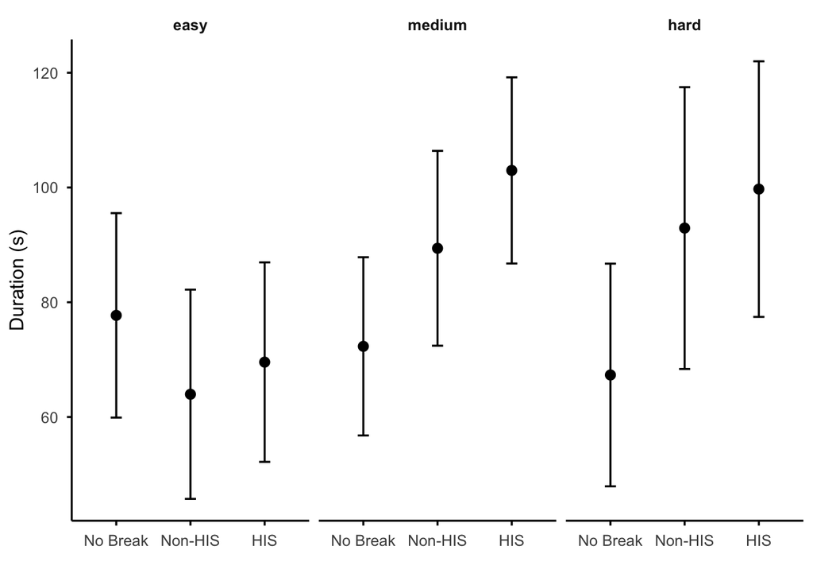

```r
preds1 <- ggpredict(model2_final, terms = c("level", "condition"))
plot1 <- ggplot(preds1, aes(x = group, y = predicted)) +
  geom_point(size = 2.5) +
  geom_errorbar(
    aes(ymin = conf.low, ymax = conf.high),
    width = 0.15,
    linewidth = 0.6
  ) +
  facet_wrap(~ x, nrow = 1) +
  labs(
    x = "",
    y = "Duration (s)"
  ) +
  theme_minimal(base_size = 12) +
  theme(
    panel.grid = element_blank(),
    strip.text = element_text(face = "bold"),
    axis.line = element_line(linewidth = 0.6, color = "black"),
    axis.ticks = element_line(linewidth = 0.6)
  )

ggsave(
  filename = "solutionTime.pdf",
  plot = plot1,
  width = 7,
  height = 3,
  units = "in"
)

plot1
```

## Clustering Analysis

We have a lot of data on the exact moves participants used while working on the puzzles. We can see how strategies shift when participants are interrupted to take a break. We can use clustering in order to cluster strategies by comparing move set similarity in each level. First, we use every participants’ move sets to build a list of every move set made.

```r
data$allMovesets <- Map(c, data$beforeBreakMovesets, data$afterBreakMovesets)

get_cleaned_movesets <- function(level_name) {
  level_rows <- data[data$level == level_name, ]
  combined_movesets <- unlist(level_rows$allMovesets, use.names = FALSE)
  filtered <- combined_movesets[nchar(combined_movesets) >= 4]
  unique(filtered)
}

easy_movesets   <- get_cleaned_movesets("easy")
medium_movesets <- get_cleaned_movesets("medium")
hard_movesets   <- get_cleaned_movesets("hard")
```

For the hard level, there are groups of moves that always occur together. To better identify strategies, we convert these patterns of moves.

```r
hard_movesets <- gsub("rrddllu", "z", hard_movesets)
hard_movesets <- gsub("drruull", "x", hard_movesets)
```

Move sets will be considered similar if they have similar prefixes. For example, lrlrudud would be similar to lrluduu. The more prefixes they have in common, the more likely they are to be similar strategies in Sokoban. We compute a distance matrix for each level.

```r
prefix_distance <- function(a, b) {
  min_len <- min(nchar(a), nchar(b))
  match_length <- 0
  for (i in seq_len(min_len)) {
    if (substr(a, i, i) != substr(b, i, i)) break
    match_length <- match_length + 1
  }
  return(1 - (match_length / min_len))
}

build_prefix_dist_matrix <- function(movesets) {
  n <- length(movesets)
  dist_mat <- matrix(0, n, n)

  for (i in 1:(n-1)) {
    for (j in (i+1):n) {
      d <- prefix_distance(movesets[i], movesets[j])
      dist_mat[i, j] <- d
      dist_mat[j, i] <- d
    }
  }

  as.dist(dist_mat)
}

easy_dist <- build_prefix_dist_matrix(easy_movesets)
medium_dist <- build_prefix_dist_matrix(medium_movesets)
hard_dist <- build_prefix_dist_matrix(hard_movesets)

easy_clust <- hclust(easy_dist, method = "complete")
medium_clust <- hclust(medium_dist, method = "complete")
hard_clust <- hclust(hard_dist, method = "complete")
```

We use silhouette analysis to determine the optimal number of clusters.

Easy Level

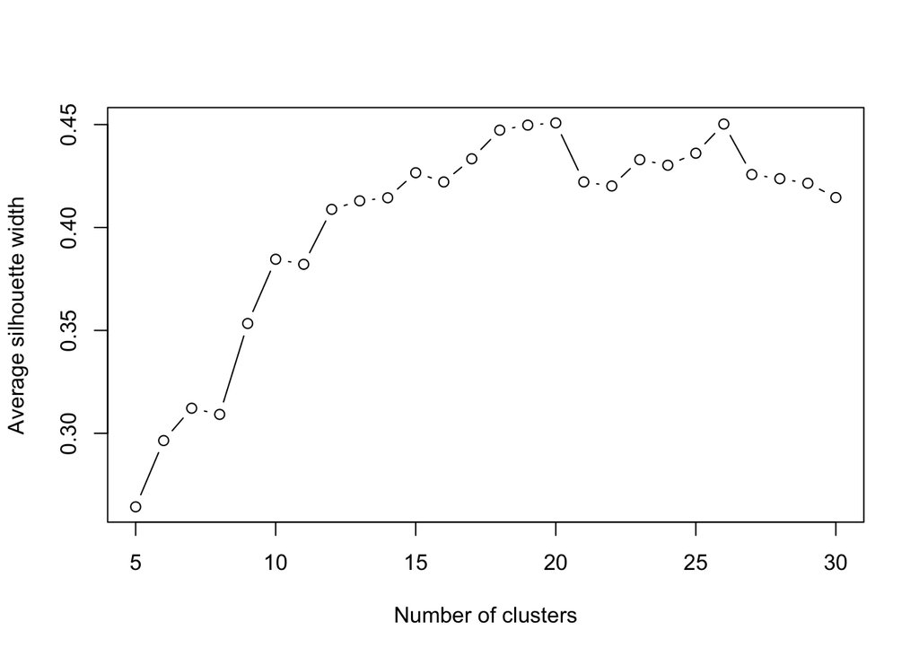

```r
avg_sil <- sapply(5:30, function(k) {
  clusters <- cutree(easy_clust, k)
  sil <- silhouette(clusters, easy_dist)
  mean(sil[, 3])
})

plot(5:30, avg_sil, type = "b",
     xlab = "Number of clusters", ylab = "Average silhouette width")
```

Medium Level

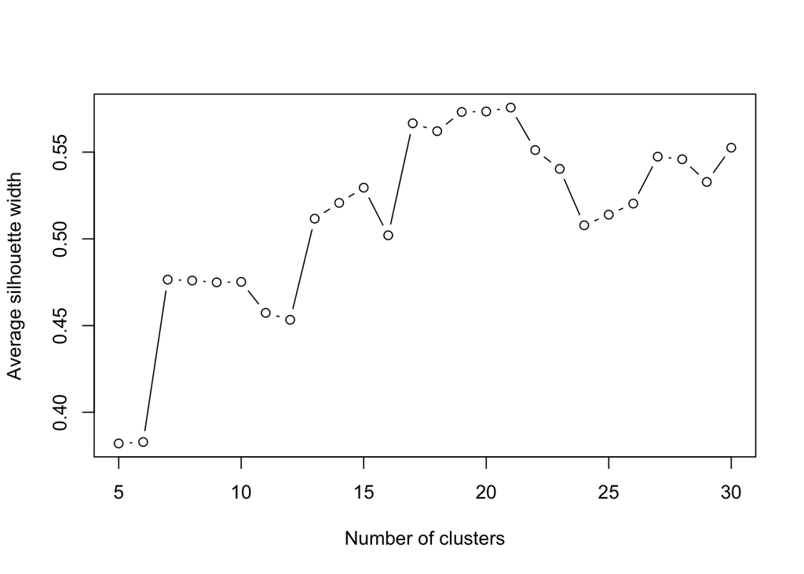

```r
avg_sil <- sapply(5:30, function(k) {
  clusters <- cutree(medium_clust, k)
  sil <- silhouette(clusters, medium_dist)
  mean(sil[, 3])
})

plot(5:30, avg_sil, type = "b",
     xlab = "Number of clusters", ylab = "Average silhouette width")
```

Hard Level

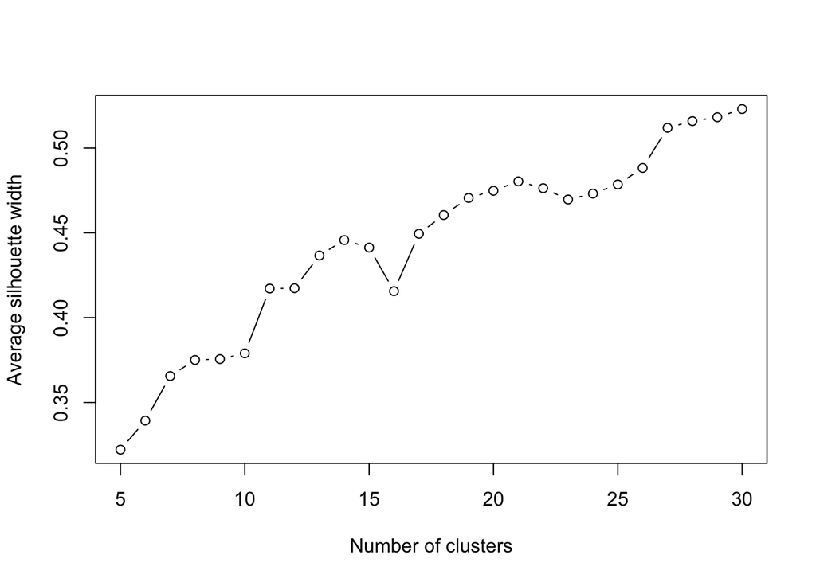

```r
avg_sil <- sapply(5:30, function(k) {
  clusters <- cutree(hard_clust, k)
  sil <- silhouette(clusters, hard_dist)
  mean(sil[, 3])
})

plot(5:30, avg_sil, type = "b",
     xlab = "Number of clusters", ylab = "Average silhouette width")
```

Based on the plots, the number of clusters for the easy, medium, and hard puzzles will be 12, 17, and 11, respectively. Using slightly different numbers of clusters results in similar results.

```r
clusters_easy <- cutree(easy_clust, k = 12)
clusters_medium <- cutree(medium_clust, k = 17)
clusters_hard <- cutree(hard_clust, k = 11)
```

We generate new data columns which show the cluster number rather than the string of moves. A very few number of participants did not have move sets before or after break and are removed from this analysis.

```r
main_data$beforeBreakMovesets <- mapply(function(moves, level) {
  moves <- moves[nchar(moves) >= 4]
  if (level == "hard") {
    moves <- gsub("rrddllu", "z", moves)
    moves <- gsub("drruull", "x", moves)
  }
  return(moves)
}, main_data$beforeBreakMovesets, main_data$level, SIMPLIFY = FALSE)

main_data$afterBreakMovesets <- mapply(function(moves, level) {
  moves <- moves[nchar(moves) >= 4]
  if (level == "hard") {
    moves <- gsub("rrddllu", "z", moves)
    moves <- gsub("drruull", "x", moves)
  }
  return(moves)
}, main_data$afterBreakMovesets, main_data$level, SIMPLIFY = FALSE)
moveset_data <- main_data[
  lengths(main_data$beforeBreakMovesets) > 0 &
  lengths(main_data$afterBreakMovesets) > 0,
]

lookup_easy <- setNames(clusters_easy, easy_movesets)
lookup_medium <- setNames(clusters_medium, medium_movesets)
lookup_hard <- setNames(clusters_hard, hard_movesets)

map_moves_to_clusters <- function(moves, level) {
  level <- as.character(level)
  lookup <- switch(level,
                   "easy" = lookup_easy,
                   "medium" = lookup_medium,
                   "hard" = lookup_hard)

  sapply(moves, function(m) lookup[[m]], USE.NAMES = FALSE)
}

moveset_data$beforeClusters <- mapply(map_moves_to_clusters,
                                   moveset_data$beforeBreakMovesets,
                                   moveset_data$level,
                                   SIMPLIFY = FALSE)

moveset_data$afterClusters <- mapply(map_moves_to_clusters,
                                  moveset_data$afterBreakMovesets,
                                  moveset_data$level,
                                  SIMPLIFY = FALSE)
```

We now create a column which displays whether an individual’s first move when returning to the problem after a break is a new strategy (new cluster) or a variation/copy of a previous strategy.

We also count the number of moves made before the break for use as a control variable, since using a new strategy is more likely if you have less moves made before the break.

```r
moveset_data$newMove <- mapply(function(before, after) {
  first_after <- after[1]
  if (first_after %in% before) 0 else 1
}, moveset_data$beforeClusters, moveset_data$afterClusters)

moveset_data$beforeBreakLength <- sapply(moveset_data$beforeBreakMovesets, length)
```

Let’s check whether different conditions or levels predict the use of new moves.

```r
model3_null <- glmer(newMove ~  (1|prolificPID), family="binomial", control = glmerControl(optimizer = "bobyqa"), data = moveset_data)
model3_base <- glmer(newMove ~  level * condition + beforeBreakLength + (1|prolificPID), family="binomial", control = glmerControl(optimizer = "bobyqa"), data = moveset_data)

summary(model3_base)
```

```
## Generalized linear mixed model fit by maximum likelihood (Laplace
##   Approximation) [glmerMod]
##  Family: binomial  ( logit )
## Formula: newMove ~ level * condition + beforeBreakLength + (1 | prolificPID)
##    Data: moveset_data
## Control: glmerControl(optimizer = "bobyqa")
##
##       AIC       BIC    logLik -2*log(L)  df.resid
##     683.9     731.0    -331.0     661.9       522
##
## Scaled residuals:
##     Min      1Q  Median      3Q     Max
## -1.7786 -0.7541 -0.4717  0.8871  2.3915
##
## Random effects:
##  Groups      Name        Variance Std.Dev.
##  prolificPID (Intercept) 0.294    0.5422
## Number of obs: 533, groups:  prolificPID, 252
##
## Fixed effects:
##                               Estimate Std. Error z value Pr(>|z|)
## (Intercept)                   1.848738   0.435188   4.248 2.16e-05 ***
## levelmedium                  -0.475798   0.443553  -1.073   0.2834
## levelhard                    -1.063275   0.432884  -2.456   0.0140 *
## conditionNon-HIS             -0.661457   0.484976  -1.364   0.1726
## conditionHIS                 -1.190130   0.511768  -2.326   0.0200 *
## beforeBreakLength            -0.309774   0.055631  -5.568 2.57e-08 ***
## levelmedium:conditionNon-HIS  0.002222   0.641513   0.003   0.9972
## levelhard:conditionNon-HIS    1.084620   0.612914   1.770   0.0768 .
## levelmedium:conditionHIS      0.875208   0.660770   1.325   0.1853
## levelhard:conditionHIS        1.068307   0.638320   1.674   0.0942 .
## ---
## Signif. codes:  0 '***' 0.001 '**' 0.01 '*' 0.05 '.' 0.1 ' ' 1
##
## Correlation of Fixed Effects:
##             (Intr) lvlmdm lvlhrd cN-HIS cndHIS bfrBrL lvlm:N-HIS lvlh:N-HIS
## levelmedium -0.633
## levelhard   -0.680  0.619
## cndtnNn-HIS -0.575  0.560  0.577
## conditinHIS -0.575  0.534  0.557  0.493
## bfrBrkLngth -0.614  0.036  0.086  0.024  0.068
## lvlmd:N-HIS  0.449 -0.705 -0.436 -0.763 -0.372 -0.030
## lvlhr:N-HIS  0.460 -0.442 -0.716 -0.800 -0.395 -0.017  0.603
## lvlmdm:cHIS  0.445 -0.686 -0.430 -0.387 -0.783 -0.044  0.477      0.307
## lvlhrd:cHIS  0.481 -0.429 -0.697 -0.396 -0.809 -0.079  0.298      0.490
##             lvlm:HIS
## levelmedium
## levelhard
## cndtnNn-HIS
## conditinHIS
## bfrBrkLngth
## lvlmd:N-HIS
## lvlhr:N-HIS
## lvlmdm:cHIS
## lvlhrd:cHIS  0.626
```

```r
r.squaredGLMM(model3_base, null = model3_null)
```

```
##                   R2m       R2c
## theoretical 0.1486770 0.2185116
## delta       0.1233586 0.1813009
```

```r
confint(model3_base, method = "Wald")
```

```
##                                   2.5 %     97.5 %
## .sig01                               NA         NA
## (Intercept)                   0.9957846  2.7016911
## levelmedium                  -1.3451455  0.3935496
## levelhard                    -1.9117116 -0.2148388
## conditionNon-HIS             -1.6119918  0.2890777
## conditionHIS                 -2.1931755 -0.1870836
## beforeBreakLength            -0.4188081 -0.2007400
## levelmedium:conditionNon-HIS -1.2551212  1.2595652
## levelhard:conditionNon-HIS   -0.1166696  2.2859101
## levelmedium:conditionHIS     -0.4198774  2.1702926
## levelhard:conditionHIS       -0.1827762  2.3193909
```

```r
exp(fixef(model3_base))
```

```
##                  (Intercept)                  levelmedium
##                    6.3517975                    0.6213890
##                    levelhard             conditionNon-HIS
##                    0.3453229                    0.5160988
##                 conditionHIS            beforeBreakLength
##                    0.3041819                    0.7336127
## levelmedium:conditionNon-HIS   levelhard:conditionNon-HIS
##                    1.0022245                    2.9583162
##     levelmedium:conditionHIS       levelhard:conditionHIS
##                    2.3993734                    2.9104489
```

```r
exp(confint(model3_base, parm = "beta_", method="Wald"))
```

```
##                                  2.5 %     97.5 %
## (Intercept)                  2.7068473 14.9049159
## levelmedium                  0.2605018  1.4822328
## levelhard                    0.1478271  0.8066714
## conditionNon-HIS             0.1994899  1.3351955
## conditionHIS                 0.1115619  0.8293744
## beforeBreakLength            0.6578304  0.8181251
## levelmedium:conditionNon-HIS 0.2850413  3.5238890
## levelhard:conditionNon-HIS   0.8898791  9.8346327
## levelmedium:conditionHIS     0.6571274  8.7608472
## levelhard:conditionHIS       0.8329545 10.1694782
```

Pairwise contrasts.

```r
emmeans(model3_base, ~ condition | level, type = "response") %>%
    pairs(adjust="none")
```

```
## level = easy:
##  contrast             odds.ratio    SE  df null z.ratio p.value
##  No Break / (Non-HIS)      1.938 0.940 Inf    1   1.364  0.1726
##  No Break / HIS            3.288 1.680 Inf    1   2.326  0.0200
##  (Non-HIS) / HIS           1.697 0.852 Inf    1   1.052  0.2926
##
## level = medium:
##  contrast             odds.ratio    SE  df null z.ratio p.value
##  No Break / (Non-HIS)      1.933 0.801 Inf    1   1.590  0.1117
##  No Break / HIS            1.370 0.564 Inf    1   0.766  0.4440
##  (Non-HIS) / HIS           0.709 0.304 Inf    1  -0.802  0.4225
##
## level = hard:
##  contrast             odds.ratio    SE  df null z.ratio p.value
##  No Break / (Non-HIS)      0.655 0.241 Inf    1  -1.152  0.2495
##  No Break / HIS            1.130 0.424 Inf    1   0.325  0.7452
##  (Non-HIS) / HIS           1.725 0.647 Inf    1   1.453  0.1463
##
## Tests are performed on the log odds ratio scale
```

Simple plot.

```r
preds2 <- ggpredict(model3_base, terms = c("level", "condition"))
```

```
## You are calculating adjusted predictions on the population-level (i.e.
##   `type = "fixed"`) for a *generalized* linear mixed model.
##   This may produce biased estimates due to Jensen's inequality. Consider
##   setting `bias_correction = TRUE` to correct for this bias.
##   See also the documentation of the `bias_correction` argument.
```

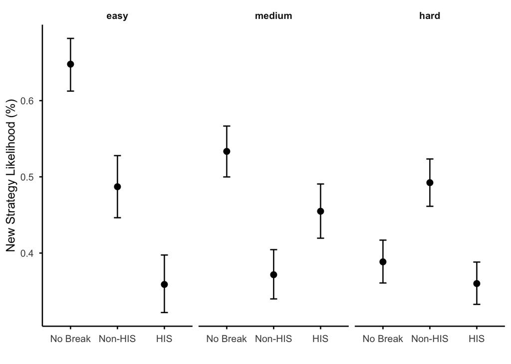

```r
plot2 <- ggplot(preds2, aes(x = group, y = predicted)) +
  geom_point(size = 2.5) +
  geom_errorbar(
    aes(ymin = conf.low, ymax = conf.high),
    width = 0.15,
    linewidth = 0.6
  ) +
  facet_wrap(~ x, nrow = 1) +
  labs(
    x = "",
    y = "New Strategy Likelihood (%)"
  ) +
  theme_minimal(base_size = 12) +
  theme(
    panel.grid = element_blank(),
    strip.text = element_text(face = "bold"),
    axis.line = element_line(linewidth = 0.6, color = "black"),
    axis.ticks = element_line(linewidth = 0.6)
  )

ggsave(
  filename = "newMove.pdf",
  plot = plot2,
  width = 7,
  height = 3,
  units = "in"
)

plot2
```